# W3cubDocs

/Matplotlib 3.5

# mpl_toolkits.mplot3d.axes3d.Axes3D

**class*mpl_toolkits.mplot3d.axes3d.Axes3D(*fig*, *rect=None*, *args, *azim=- 60*, *elev=30*, *sharez=None*, *proj_type='persp'*, *box_aspect=None*, *computed_zorder=True*, **kwargs)[[source]](https://github.com/matplotlib/matplotlib/blob/v3.5.1/lib/mpl_toolkits/mplot3d/axes3d.py#L44-L3490)**

Bases: `matplotlib.axes._axes.Axes`

3D axes object.

**Parameters**

**fig**Figure**

The parent figure.

**rect**(float, float, float, float)**

The `(left, bottom, width, height)` axes position.

**azim**float, default: -60**

Azimuthal viewing angle.

**elev**float, default: 30**

Elevation viewing angle.

**sharez**Axes3D, optional**

Other axes to share z-limits with.

**proj_type**{'persp', 'ortho'}**

The projection type, default 'persp'.

**computed_zorder**bool, default: True**

If True, the draw order is computed based on the average position of the `Artist`s along the view direction. Set to False if you want to manually control the order in which Artists are drawn on top of each other using their *zorder* attribute. This can be used for fine-tuning if the automatic order does not produce the desired result. Note however, that a manual zorder will only be correct for a limited view angle. If the figure is rotated by the user, it will look wrong from certain angles.

**auto_add_to_figure**bool, default: True**

Prior to Matplotlib 3.4 Axes3D would add themselves to their host Figure on init. Other Axes class do not do this.

This behavior is deprecated in 3.4, the default will change to False in 3.5. The keyword will be undocumented and a non-False value will be an error in 3.6.

**kwargs**

Other optional keyword arguments:

| Property | Description |
| --- | --- |
| `adjustable` | {'box', 'datalim'} |
| `agg_filter` | a filter function, which takes a (m, n, 3) float array and a dpi value, and returns a (m, n, 3) array |
| `alpha` | scalar or None |
| `anchor` | (float, float) or {'C', 'SW', 'S', 'SE', 'E', 'NE', ...} |
| `animated` | bool |
| `aspect` | {'auto'} |
| `autoscale_on` | unknown |
| `autoscalex_on` | bool |
| `autoscaley_on` | bool |
| `autoscalez_on` | bool |
| `axes_locator` | Callable[[Axes, Renderer], Bbox] |
| `axisbelow` | bool or 'line' |
| `box_aspect` | 3-tuple of floats or None |
| `clip_box` | `Bbox` |
| `clip_on` | bool |
| `clip_path` | Patch or (Path, Transform) or None |
| `facecolor` or fc | color |
| `figure` | `Figure` |
| `frame_on` | bool |
| `gid` | str |
| `in_layout` | bool |
| `label` | object |
| `navigate` | bool |
| `navigate_mode` | unknown |
| `path_effects` | `AbstractPathEffect` |
| `picker` | None or bool or float or callable |
| `position` | [left, bottom, width, height] or `Bbox` |
| `proj_type` | {'persp', 'ortho'} |
| `prop_cycle` | unknown |
| `rasterization_zorder` | float or None |
| `rasterized` | bool |
| `sketch_params` | (scale: float, length: float, randomness: float) |
| `snap` | bool or None |
| `title` | unknown |
| `transform` | `Transform` |
| `url` | str |
| `visible` | bool |
| `xbound` | unknown |
| `xlabel` | str |
| `xlim3d` or xlim | unknown |
| `xmargin` | unknown |
| `xscale` | {"linear"} |
| `xticklabels` | unknown |
| `xticks` | unknown |
| `ybound` | unknown |
| `ylabel` | str |
| `ylim3d` or ylim | unknown |
| `ymargin` | unknown |
| `yscale` | {"linear"} |
| `yticklabels` | unknown |
| `yticks` | unknown |
| `zbound` | unknown |
| `zlabel` | unknown |
| `zlim3d` or zlim | unknown |
| `zmargin` | unknown |
| `zorder` | float |
| `zscale` | {"linear"} |
| `zticklabels` | unknown |
| `zticks` | unknown |

**add_collection3d(*col*, *zs=0*, *zdir='z'*)[[source]](https://github.com/matplotlib/matplotlib/blob/v3.5.1/lib/mpl_toolkits/mplot3d/axes3d.py#L2293-L2324)**

Add a 3D collection object to the plot.

2D collection types are converted to a 3D version by modifying the object and adding z coordinate information.

Supported are:

- PolyCollection
- LineCollection
- PatchCollection

**add_contour_set(*cset*, *extend3d=False*, *stride=5*, *zdir='z'*, *offset=None*)[[source]](https://github.com/matplotlib/matplotlib/blob/v3.5.1/lib/mpl_toolkits/mplot3d/axes3d.py#L2064-L2073)**

**add_contourf_set(*cset*, *zdir='z'*, *offset=None*)[[source]](https://github.com/matplotlib/matplotlib/blob/v3.5.1/lib/mpl_toolkits/mplot3d/axes3d.py#L2075-L2076)**

**apply_aspect(*position=None*)[[source]](https://github.com/matplotlib/matplotlib/blob/v3.5.1/lib/mpl_toolkits/mplot3d/axes3d.py#L360-L375)**

Adjust the Axes for a specified data aspect ratio.

Depending on `get_adjustable` this will modify either the Axes box (position) or the view limits. In the former case, `get_anchor` will affect the position.

See also

**`matplotlib.axes.Axes.set_aspect`**

For a description of aspect ratio handling.

**`matplotlib.axes.Axes.set_adjustable`**

Set how the Axes adjusts to achieve the required aspect ratio.

**`matplotlib.axes.Axes.set_anchor`**

Set the position in case of extra space.

#### Notes

This is called automatically when each Axes is drawn. You may need to call it yourself if you need to update the Axes position and/or view limits before the Figure is drawn.

**auto_scale_xyz(*X*, *Y*, *Z=None*, *had_data=None*)[[source]](https://github.com/matplotlib/matplotlib/blob/v3.5.1/lib/mpl_toolkits/mplot3d/axes3d.py#L648-L660)**

**autoscale(*enable=True*, *axis='both'*, *tight=None*)[[source]](https://github.com/matplotlib/matplotlib/blob/v3.5.1/lib/mpl_toolkits/mplot3d/axes3d.py#L620-L646)**

Convenience method for simple axis view autoscaling. See `matplotlib.axes.Axes.autoscale()` for full explanation. Note that this function behaves the same, but for all three axes. Therefore, 'z' can be passed for *axis*, and 'both' applies to all three axes.

**autoscale_view(*tight=None*, *scalex=True*, *scaley=True*, *scalez=True*)[[source]](https://github.com/matplotlib/matplotlib/blob/v3.5.1/lib/mpl_toolkits/mplot3d/axes3d.py#L662-L722)**

Autoscale the view limits using the data limits. See `matplotlib.axes.Axes.autoscale_view()` for documentation. Note that this function applies to the 3D axes, and as such adds the *scalez* to the function arguments.

**bar(*left*, *height*, *zs=0*, *zdir='z'*, *args, *data=None*, **kwargs)[[source]](https://github.com/matplotlib/matplotlib/blob/v3.5.1/lib/mpl_toolkits/mplot3d/axes3d.py#L2402-L2454)**

Add 2D bar(s).

**Parameters**

**left**1D array-like**

The x coordinates of the left sides of the bars.

**height**1D array-like**

The height of the bars.

**zs**float or 1D array-like**

Z coordinate of bars; if a single value is specified, it will be used for all bars.

**zdir**{'x', 'y', 'z'}, default: 'z'**

When plotting 2D data, the direction to use as z ('x', 'y' or 'z').

**data**indexable object, optional**

If given, all parameters also accept a string `s`, which is interpreted as `data[s]` (unless this raises an exception).

**kwargs**

Other arguments are forwarded to `matplotlib.axes.Axes.bar`.

**Returns**

**mpl_toolkits.mplot3d.art3d.Patch3DCollection**

**bar3d(*x*, *y*, *z*, *dx*, *dy*, *dz*, *color=None*, *zsort='average'*, *shade=True*, *lightsource=None*, *args, *data=None*, **kwargs)[[source]](https://github.com/matplotlib/matplotlib/blob/v3.5.1/lib/mpl_toolkits/mplot3d/axes3d.py#L2456-L2620)**

Generate a 3D barplot.

This method creates three dimensional barplot where the width, depth, height, and color of the bars can all be uniquely set.

**Parameters**

**x, y, z**array-like**

The coordinates of the anchor point of the bars.

**dx, dy, dz**float or array-like**

The width, depth, and height of the bars, respectively.

**color**sequence of colors, optional**

The color of the bars can be specified globally or individually. This parameter can be:

- A single color, to color all bars the same color.
- An array of colors of length N bars, to color each bar independently.
- An array of colors of length 6, to color the faces of the bars similarly.
- An array of colors of length 6 * N bars, to color each face independently.

When coloring the faces of the boxes specifically, this is the order of the coloring:

1. -Z (bottom of box)
2. +Z (top of box)
3. -Y
4. +Y
5. -X
6. +X

**zsort**str, optional**

The z-axis sorting scheme passed onto `Poly3DCollection`

**shade**bool, default: True**

When true, this shades the dark sides of the bars (relative to the plot's source of light).

**lightsource**`LightSource`**

The lightsource to use when *shade* is True.

**data**indexable object, optional**

If given, all parameters also accept a string `s`, which is interpreted as `data[s]` (unless this raises an exception).

**kwargs**

Any additional keyword arguments are passed onto `Poly3DCollection`.

**Returns**

**collection**`Poly3DCollection`**

A collection of three dimensional polygons representing the bars.

**can_pan()[[source]](https://github.com/matplotlib/matplotlib/blob/v3.5.1/lib/mpl_toolkits/mplot3d/axes3d.py#L1120-L1126)**

Return whether this axes supports the pan/zoom button functionality.

3D axes objects do not use the pan/zoom button.

**can_zoom()[[source]](https://github.com/matplotlib/matplotlib/blob/v3.5.1/lib/mpl_toolkits/mplot3d/axes3d.py#L1112-L1118)**

Return whether this axes supports the zoom box button functionality.

3D axes objects do not use the zoom box button.

**cla()[[source]](https://github.com/matplotlib/matplotlib/blob/v3.5.1/lib/mpl_toolkits/mplot3d/axes3d.py#L1128-L1153)**

Clear the Axes.

**clabel(*args, **kwargs)[[source]](https://github.com/matplotlib/matplotlib/blob/v3.5.1/lib/mpl_toolkits/mplot3d/axes3d.py#L979-L981)**

Currently not implemented for 3D axes, and returns *None*.

**contour(*X*, *Y*, *Z*, *args, *extend3d=False*, *stride=5*, *zdir='z'*, *offset=None*, *data=None*, **kwargs)[[source]](https://github.com/matplotlib/matplotlib/blob/v3.5.1/lib/mpl_toolkits/mplot3d/axes3d.py#L2103-L2140)**

Create a 3D contour plot.

**Parameters**

**X, Y, Z**array-like,**

Input data. See `contour` for acceptable data shapes.

**extend3d**bool, default: False**

Whether to extend contour in 3D.

**stride**int**

Step size for extending contour.

**zdir**{'x', 'y', 'z'}, default: 'z'**

The direction to use.

**offset**float, optional**

If specified, plot a projection of the contour lines at this position in a plane normal to zdir.

**data**indexable object, optional**

If given, all parameters also accept a string `s`, which is interpreted as `data[s]` (unless this raises an exception).

**args, **kwargs**

Other arguments are forwarded to `matplotlib.axes.Axes.contour`.

**Returns**

**matplotlib.contour.QuadContourSet**

**contour3D(*X*, *Y*, *Z*, *args, *extend3d=False*, *stride=5*, *zdir='z'*, *offset=None*, *data=None*, **kwargs)[[source]](https://github.com/matplotlib/matplotlib/blob/v3.5.1/lib/mpl_toolkits/mplot3d/axes3d.py#L2103-L2140)**

Create a 3D contour plot.

**Parameters**

**X, Y, Z**array-like,**

Input data. See `contour` for acceptable data shapes.

**extend3d**bool, default: False**

Whether to extend contour in 3D.

**stride**int**

Step size for extending contour.

**zdir**{'x', 'y', 'z'}, default: 'z'**

The direction to use.

**offset**float, optional**

If specified, plot a projection of the contour lines at this position in a plane normal to zdir.

**data**indexable object, optional**

If given, all parameters also accept a string `s`, which is interpreted as `data[s]` (unless this raises an exception).

**args, **kwargs**

Other arguments are forwarded to `matplotlib.axes.Axes.contour`.

**Returns**

**matplotlib.contour.QuadContourSet**

**contourf(*X*, *Y*, *Z*, *args, *zdir='z'*, *offset=None*, *data=None*, **kwargs)[[source]](https://github.com/matplotlib/matplotlib/blob/v3.5.1/lib/mpl_toolkits/mplot3d/axes3d.py#L2208-L2239)**

Create a 3D filled contour plot.

**Parameters**

**X, Y, Z**array-like**

Input data. See `contourf` for acceptable data shapes.

**zdir**{'x', 'y', 'z'}, default: 'z'**

The direction to use.

**offset**float, optional**

If specified, plot a projection of the contour lines at this position in a plane normal to zdir.

**data**indexable object, optional**

If given, all parameters also accept a string `s`, which is interpreted as `data[s]` (unless this raises an exception).

**args, **kwargs**

Other arguments are forwarded to `matplotlib.axes.Axes.contourf`.

**Returns**

**matplotlib.contour.QuadContourSet**

**contourf3D(*X*, *Y*, *Z*, *args, *zdir='z'*, *offset=None*, *data=None*, **kwargs)[[source]](https://github.com/matplotlib/matplotlib/blob/v3.5.1/lib/mpl_toolkits/mplot3d/axes3d.py#L2208-L2239)**

Create a 3D filled contour plot.

**Parameters**

**X, Y, Z**array-like**

Input data. See `contourf` for acceptable data shapes.

**zdir**{'x', 'y', 'z'}, default: 'z'**

The direction to use.

**offset**float, optional**

If specified, plot a projection of the contour lines at this position in a plane normal to zdir.

**data**indexable object, optional**

If given, all parameters also accept a string `s`, which is interpreted as `data[s]` (unless this raises an exception).

**args, **kwargs**

Other arguments are forwarded to `matplotlib.axes.Axes.contourf`.

**Returns**

**matplotlib.contour.QuadContourSet**

**convert_zunits(*z*)[[source]](https://github.com/matplotlib/matplotlib/blob/v3.5.1/lib/mpl_toolkits/mplot3d/axes3d.py#L177-L182)**

For artists in an axes, if the zaxis has units support, convert *z* using zaxis unit type

**disable_mouse_rotation()[[source]](https://github.com/matplotlib/matplotlib/blob/v3.5.1/lib/mpl_toolkits/mplot3d/axes3d.py#L1108-L1110)**

Disable mouse buttons for 3D rotation and zooming.

**draw(*renderer*)[[source]](https://github.com/matplotlib/matplotlib/blob/v3.5.1/lib/matplotlib/artist.py#L377-L473)**

Draw the Artist (and its children) using the given renderer.

This has no effect if the artist is not visible (`Artist.get_visible` returns False).

**Parameters**

**renderer**`RendererBase` subclass.**

#### Notes

This method is overridden in the Artist subclasses.

**errorbar(*x*, *y*, *z*, *zerr=None*, *yerr=None*, *xerr=None*, *fmt=''*, *barsabove=False*, *errorevery=1*, *ecolor=None*, *elinewidth=None*, *capsize=None*, *capthick=None*, *xlolims=False*, *xuplims=False*, *ylolims=False*, *yuplims=False*, *zlolims=False*, *zuplims=False*, *, *data=None*, **kwargs)[[source]](https://github.com/matplotlib/matplotlib/blob/v3.5.1/lib/mpl_toolkits/mplot3d/axes3d.py#L2998-L3349)**

Plot lines and/or markers with errorbars around them.

*x*/*y*/*z* define the data locations, and *xerr*/*yerr*/*zerr* define the errorbar sizes. By default, this draws the data markers/lines as well the errorbars. Use fmt='none' to draw errorbars only.

**Parameters**

**x, y, z**float or array-like**

The data positions.

**xerr, yerr, zerr**float or array-like, shape (N,) or (2, N), optional**

The errorbar sizes:

- scalar: Symmetric +/- values for all data points.
- shape(N,): Symmetric +/-values for each data point.
- shape(2, N): Separate - and + values for each bar. First row contains the lower errors, the second row contains the upper errors.
- *None*: No errorbar.

Note that all error arrays should have *positive* values.

**fmt**str, default: ''**

The format for the data points / data lines. See `plot` for details.

Use 'none' (case insensitive) to plot errorbars without any data markers.

**ecolor**color, default: None**

The color of the errorbar lines. If None, use the color of the line connecting the markers.

**elinewidth**float, default: None**

The linewidth of the errorbar lines. If None, the linewidth of the current style is used.

**capsize**float, default: `rcParams["errorbar.capsize"]` (default: `0.0`)**

The length of the error bar caps in points.

**capthick**float, default: None**

An alias to the keyword argument *markeredgewidth* (a.k.a. *mew*). This setting is a more sensible name for the property that controls the thickness of the error bar cap in points. For backwards compatibility, if *mew* or *markeredgewidth* are given, then they will over-ride *capthick*. This may change in future releases.

**barsabove**bool, default: False**

If True, will plot the errorbars above the plot symbols. Default is below.

**xlolims, ylolims, zlolims**bool, default: False**

These arguments can be used to indicate that a value gives only lower limits. In that case a caret symbol is used to indicate this. *lims*-arguments may be scalars, or array-likes of the same length as the errors. To use limits with inverted axes, `set_xlim` or `set_ylim` must be called before `errorbar()`. Note the tricky parameter names: setting e.g. *ylolims* to True means that the y-value is a *lower* limit of the True value, so, only an *upward*-pointing arrow will be drawn!

**xuplims, yuplims, zuplims**bool, default: False**

Same as above, but for controlling the upper limits.

**errorevery**int or (int, int), default: 1**

draws error bars on a subset of the data. *errorevery* =N draws error bars on the points (x[::N], y[::N], z[::N]). *errorevery* =(start, N) draws error bars on the points (x[start::N], y[start::N], z[start::N]). e.g. errorevery=(6, 3) adds error bars to the data at (x[6], x[9], x[12], x[15], ...). Used to avoid overlapping error bars when two series share x-axis values.

**Returns**

**errlines**list**

List of `Line3DCollection` instances each containing an errorbar line.

**caplines**list**

List of `Line3D` instances each containing a capline object.

**limmarks**list**

List of `Line3D` instances each containing a marker with an upper or lower limit.

**Other Parameters**

**data**indexable object, optional**

If given, the following parameters also accept a string `s`, which is interpreted as `data[s]` (unless this raises an exception):

*x*, *y*, *z*, *xerr*, *yerr*, *zerr*

**kwargs**

All other keyword arguments for styling errorbar lines are passed `Line3DCollection`.

#### Examples

([Source code](https://matplotlib.org/3.5.1/gallery/mplot3d/errorbar3d.py), png, pdf)

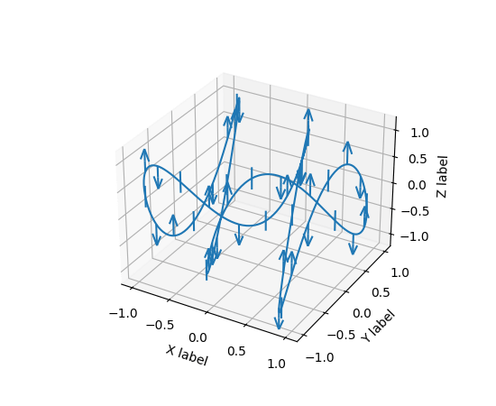

**format_coord(*xd*, *yd*)[[source]](https://github.com/matplotlib/matplotlib/blob/v3.5.1/lib/mpl_toolkits/mplot3d/axes3d.py#L1194-L1228)**

Given the 2D view coordinates attempt to guess a 3D coordinate. Looks for the nearest edge to the point and then assumes that the point is at the same z location as the nearest point on the edge.

**format_zdata(*z*)[[source]](https://github.com/matplotlib/matplotlib/blob/v3.5.1/lib/mpl_toolkits/mplot3d/axes3d.py#L1181-L1192)**

Return *z* string formatted. This function will use the `fmt_zdata` attribute if it is callable, else will fall back on the zaxis major formatter

**get_autoscale_on()[[source]](https://github.com/matplotlib/matplotlib/blob/v3.5.1/lib/mpl_toolkits/mplot3d/axes3d.py#L497-L499)**

Return True if each axis is autoscaled, False otherwise.

**get_autoscalez_on()[[source]](https://github.com/matplotlib/matplotlib/blob/v3.5.1/lib/mpl_toolkits/mplot3d/axes3d.py#L501-L503)**

Return whether the z-axis is autoscaled.

**get_axis_position()[[source]](https://github.com/matplotlib/matplotlib/blob/v3.5.1/lib/mpl_toolkits/mplot3d/axes3d.py#L475-L481)**

**get_frame_on()[[source]](https://github.com/matplotlib/matplotlib/blob/v3.5.1/lib/mpl_toolkits/mplot3d/axes3d.py#L1318-L1320)**

Get whether the 3D axes panels are drawn.

**get_proj()[[source]](https://github.com/matplotlib/matplotlib/blob/v3.5.1/lib/mpl_toolkits/mplot3d/axes3d.py#L1036-L1088)**

Create the projection matrix from the current viewing position.

**get_tightbbox(*renderer*, *call_axes_locator=True*, *bbox_extra_artists=None*, *, *for_layout_only=False*)[[source]](https://github.com/matplotlib/matplotlib/blob/v3.5.1/lib/mpl_toolkits/mplot3d/axes3d.py#L3351-L3371)**

Return the tight bounding box of the axes, including axis and their decorators (xlabel, title, etc).

Artists that have `artist.set_in_layout(False)` are not included in the bbox.

**Parameters**

**renderer**`RendererBase` subclass**

renderer that will be used to draw the figures (i.e. `fig.canvas.get_renderer()`)

**bbox_extra_artists**list of `Artist` or `None`**

List of artists to include in the tight bounding box. If `None` (default), then all artist children of the Axes are included in the tight bounding box.

**call_axes_locator**bool, default: True**

If *call_axes_locator* is `False`, it does not call the `_axes_locator` attribute, which is necessary to get the correct bounding box. `call_axes_locator=False` can be used if the caller is only interested in the relative size of the tightbbox compared to the Axes bbox.

**for_layout_only**default: False**

The bounding box will *not* include the x-extent of the title and the xlabel, or the y-extent of the ylabel.

**Returns**

**`BboxBase`**

Bounding box in figure pixel coordinates.

See also

**`matplotlib.axes.Axes.get_window_extent`**

**`matplotlib.axis.Axis.get_tightbbox`**

**`matplotlib.spines.Spine.get_window_extent`**

**get_w_lims()[[source]](https://github.com/matplotlib/matplotlib/blob/v3.5.1/lib/mpl_toolkits/mplot3d/axes3d.py#L724-L729)**

Get 3D world limits.

**get_xlim()[[source]](https://github.com/matplotlib/matplotlib/blob/v3.5.1/lib/mpl_toolkits/mplot3d/axes3d.py#L904-L905)**

Alias for `get_xlim3d`.

**get_xlim3d()[[source]](https://github.com/matplotlib/matplotlib/blob/v3.5.1/lib/mpl_toolkits/mplot3d/axes3d.py#L904-L905)**

Return the x-axis view limits.

**Returns**

**left, right**(float, float)**

The current x-axis limits in data coordinates.

See also

**`set_xlim`**

**`set_xbound`, `get_xbound`**

**`invert_xaxis`, `xaxis_inverted`**

#### Notes

The x-axis may be inverted, in which case the *left* value will be greater than the *right* value.

**get_ylim()[[source]](https://github.com/matplotlib/matplotlib/blob/v3.5.1/lib/mpl_toolkits/mplot3d/axes3d.py#L908-L909)**

Alias for `get_ylim3d`.

**get_ylim3d()[[source]](https://github.com/matplotlib/matplotlib/blob/v3.5.1/lib/mpl_toolkits/mplot3d/axes3d.py#L908-L909)**

Return the y-axis view limits.

**Returns**

**bottom, top**(float, float)**

The current y-axis limits in data coordinates.

See also

**`set_ylim`**

**`set_ybound`, `get_ybound`**

**`invert_yaxis`, `yaxis_inverted`**

#### Notes

The y-axis may be inverted, in which case the *bottom* value will be greater than the *top* value.

**get_zaxis()[[source]](https://github.com/matplotlib/matplotlib/blob/v3.5.1/lib/mpl_toolkits/mplot3d/axes3d.py#L207-L209)**

Return the `ZAxis` (`Axis`) instance.

**get_zbound()[[source]](https://github.com/matplotlib/matplotlib/blob/v3.5.1/lib/mpl_toolkits/mplot3d/axes3d.py#L1421-L1429)**

Return the lower and upper z-axis bounds, in increasing order.

**get_zgridlines()[[source]](https://github.com/matplotlib/matplotlib/blob/v3.5.1/lib/matplotlib/axes/_base.py#L74-L75)**

Return the zaxis' grid lines as a list of `Line2D`s.

**get_zlabel()[[source]](https://github.com/matplotlib/matplotlib/blob/v3.5.1/lib/mpl_toolkits/mplot3d/axes3d.py#L1309-L1314)**

Get the z-label text string.

**get_zlim()[[source]](https://github.com/matplotlib/matplotlib/blob/v3.5.1/lib/mpl_toolkits/mplot3d/axes3d.py#L912-L914)**

Alias for `get_zlim3d`.

**get_zlim3d()[[source]](https://github.com/matplotlib/matplotlib/blob/v3.5.1/lib/mpl_toolkits/mplot3d/axes3d.py#L912-L914)**

Get 3D z limits.

**get_zmajorticklabels()[[source]](https://github.com/matplotlib/matplotlib/blob/v3.5.1/lib/matplotlib/axes/_base.py#L74-L75)**

Return the zaxis' major tick labels, as a list of `Text`.

**get_zminorticklabels()[[source]](https://github.com/matplotlib/matplotlib/blob/v3.5.1/lib/matplotlib/axes/_base.py#L74-L75)**

Return the zaxis' minor tick labels, as a list of `Text`.

**get_zscale()[[source]](https://github.com/matplotlib/matplotlib/blob/v3.5.1/lib/mpl_toolkits/mplot3d/axes3d.py#L916-L921)**

**get_zticklabels(*minor=False*, *which=None*)[[source]](https://github.com/matplotlib/matplotlib/blob/v3.5.1/lib/matplotlib/axes/_base.py#L74-L75)**

Get the zaxis' tick labels.

**Parameters**

**minor**bool**

Whether to return the minor or the major ticklabels.

**which**None, ('minor', 'major', 'both')**

Overrides *minor*.

Selects which ticklabels to return

**Returns**

**list of `Text`**

#### Notes

The tick label strings are not populated until a `draw` method has been called.

See also: `draw` and `draw`.

**get_zticklines(*minor=False*)[[source]](https://github.com/matplotlib/matplotlib/blob/v3.5.1/lib/matplotlib/axes/_base.py#L74-L75)**

Return the zaxis' tick lines as a list of `Line2D`s.

**get_zticks(*, *minor=False*)[[source]](https://github.com/matplotlib/matplotlib/blob/v3.5.1/lib/matplotlib/axes/_base.py#L74-L75)**

Return the zaxis' tick locations in data coordinates.

**grid(*visible=True*, **kwargs)[[source]](https://github.com/matplotlib/matplotlib/blob/v3.5.1/lib/matplotlib/_api/deprecation.py#L1333-L1348)**

Set / unset 3D grid.

Note

Currently, this function does not behave the same as `matplotlib.axes.Axes.grid()`, but it is intended to eventually support that behavior.

**invert_zaxis()[[source]](https://github.com/matplotlib/matplotlib/blob/v3.5.1/lib/mpl_toolkits/mplot3d/axes3d.py#L1407-L1412)**

Invert the z-axis.

**locator_params(*axis='both'*, *tight=None*, **kwargs)[[source]](https://github.com/matplotlib/matplotlib/blob/v3.5.1/lib/mpl_toolkits/mplot3d/axes3d.py#L1350-L1371)**

Convenience method for controlling tick locators.

See `matplotlib.axes.Axes.locator_params()` for full documentation. Note that this is for Axes3D objects, therefore, setting *axis* to 'both' will result in the parameters being set for all three axes. Also, *axis* can also take a value of 'z' to apply parameters to the z axis.

**margins(*margins, *x=None*, *y=None*, *z=None*, *tight=True*)[[source]](https://github.com/matplotlib/matplotlib/blob/v3.5.1/lib/mpl_toolkits/mplot3d/axes3d.py#L554-L618)**

Convenience method to set or retrieve autoscaling margins.

Call signatures:

```
margins()
```

returns xmargin, ymargin, zmargin

```
margins(margin)

margins(xmargin, ymargin, zmargin)

margins(x=xmargin, y=ymargin, z=zmargin)

margins(..., tight=False)
```

All forms above set the xmargin, ymargin and zmargin parameters. All keyword parameters are optional. A single positional argument specifies xmargin, ymargin and zmargin. Passing both positional and keyword arguments for xmargin, ymargin, and/or zmargin is invalid.

The *tight* parameter is passed to `autoscale_view()`, which is executed after a margin is changed; the default here is *True*, on the assumption that when margins are specified, no additional padding to match tick marks is usually desired. Setting *tight* to *None* will preserve the previous setting.

Specifying any margin changes only the autoscaling; for example, if *xmargin* is not None, then *xmargin* times the X data interval will be added to each end of that interval before it is used in autoscaling.

**mouse_init(*rotate_btn=1*, *zoom_btn=3*)[[source]](https://github.com/matplotlib/matplotlib/blob/v3.5.1/lib/mpl_toolkits/mplot3d/axes3d.py#L1090-L1106)**

Set the mouse buttons for 3D rotation and zooming.

**Parameters**

**rotate_btn**int or list of int, default: 1**

The mouse button or buttons to use for 3D rotation of the axes.

**zoom_btn**int or list of int, default: 3**

The mouse button or buttons to use to zoom the 3D axes.

**name*='3d'**

**plot(*xs*, *ys*, *args, *zdir='z'*, **kwargs)[[source]](https://github.com/matplotlib/matplotlib/blob/v3.5.1/lib/mpl_toolkits/mplot3d/axes3d.py#L1464-L1503)**

Plot 2D or 3D data.

**Parameters**

**xs**1D array-like**

x coordinates of vertices.

**ys**1D array-like**

y coordinates of vertices.

**zs**float or 1D array-like**

z coordinates of vertices; either one for all points or one for each point.

**zdir**{'x', 'y', 'z'}, default: 'z'**

When plotting 2D data, the direction to use as z ('x', 'y' or 'z').

**kwargs**

Other arguments are forwarded to `matplotlib.axes.Axes.plot`.

**plot3D(*xs*, *ys*, *args, *zdir='z'*, **kwargs)[[source]](https://github.com/matplotlib/matplotlib/blob/v3.5.1/lib/mpl_toolkits/mplot3d/axes3d.py#L1464-L1503)**

Plot 2D or 3D data.

**Parameters**

**xs**1D array-like**

x coordinates of vertices.

**ys**1D array-like**

y coordinates of vertices.

**zs**float or 1D array-like**

z coordinates of vertices; either one for all points or one for each point.

**zdir**{'x', 'y', 'z'}, default: 'z'**

When plotting 2D data, the direction to use as z ('x', 'y' or 'z').

**kwargs**

Other arguments are forwarded to `matplotlib.axes.Axes.plot`.

**plot_surface(*X*, *Y*, *Z*, *args, *norm=None*, *vmin=None*, *vmax=None*, *lightsource=None*, **kwargs)[[source]](https://github.com/matplotlib/matplotlib/blob/v3.5.1/lib/matplotlib/_api/deprecation.py#L1507-L1712)**

Create a surface plot.

By default it will be colored in shades of a solid color, but it also supports colormapping by supplying the *cmap* argument.

Note

The *rcount* and *ccount* kwargs, which both default to 50, determine the maximum number of samples used in each direction. If the input data is larger, it will be downsampled (by slicing) to these numbers of points.

Note

To maximize rendering speed consider setting *rstride* and *cstride* to divisors of the number of rows minus 1 and columns minus 1 respectively. For example, given 51 rows rstride can be any of the divisors of 50.

Similarly, a setting of *rstride* and *cstride* equal to 1 (or *rcount* and *ccount* equal the number of rows and columns) can use the optimized path.

**Parameters**

**X, Y, Z**2D arrays**

Data values.

**rcount, ccount**int**

Maximum number of samples used in each direction. If the input data is larger, it will be downsampled (by slicing) to these numbers of points. Defaults to 50.

**rstride, cstride**int**

Downsampling stride in each direction. These arguments are mutually exclusive with *rcount* and *ccount*. If only one of *rstride* or *cstride* is set, the other defaults to 10.

'classic' mode uses a default of `rstride = cstride = 10` instead of the new default of `rcount = ccount = 50`.

**color**color-like**

Color of the surface patches.

**cmap**Colormap**

Colormap of the surface patches.

**facecolors**array-like of colors.**

Colors of each individual patch.

**norm**Normalize**

Normalization for the colormap.

**vmin, vmax**float**

Bounds for the normalization.

**shade**bool, default: True**

Whether to shade the facecolors. Shading is always disabled when *cmap* is specified.

**lightsource**`LightSource`**

The lightsource to use when *shade* is True.

**kwargs**

Other arguments are forwarded to `Poly3DCollection`.

**plot_trisurf(*args, *color=None*, *norm=None*, *vmin=None*, *vmax=None*, *lightsource=None*, **kwargs)[[source]](https://github.com/matplotlib/matplotlib/blob/v3.5.1/lib/mpl_toolkits/mplot3d/axes3d.py#L1912-L2011)**

Plot a triangulated surface.

The (optional) triangulation can be specified in one of two ways; either:

```
plot_trisurf(triangulation, ...)
```

where triangulation is a `Triangulation` object, or:

```
plot_trisurf(X, Y, ...)
plot_trisurf(X, Y, triangles, ...)
plot_trisurf(X, Y, triangles=triangles, ...)
```

in which case a Triangulation object will be created. See `Triangulation` for a explanation of these possibilities.

The remaining arguments are:

```
plot_trisurf(..., Z)
```

where *Z* is the array of values to contour, one per point in the triangulation.

**Parameters**

**X, Y, Z**array-like**

Data values as 1D arrays.

**color**

Color of the surface patches.

**cmap**

A colormap for the surface patches.

**norm**Normalize**

An instance of Normalize to map values to colors.

**vmin, vmax**float, default: None**

Minimum and maximum value to map.

**shade**bool, default: True**

Whether to shade the facecolors. Shading is always disabled when *cmap* is specified.

**lightsource**`LightSource`**

The lightsource to use when *shade* is True.

**kwargs**

All other arguments are passed on to `Poly3DCollection`

#### Examples

([Source code](https://matplotlib.org/3.5.1/gallery/mplot3d/trisurf3d.py), png, pdf)

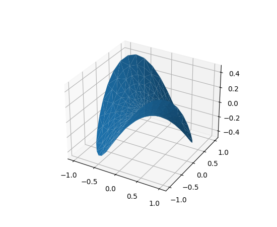

([Source code](https://matplotlib.org/3.5.1/gallery/mplot3d/trisurf3d_2.py), png, pdf)

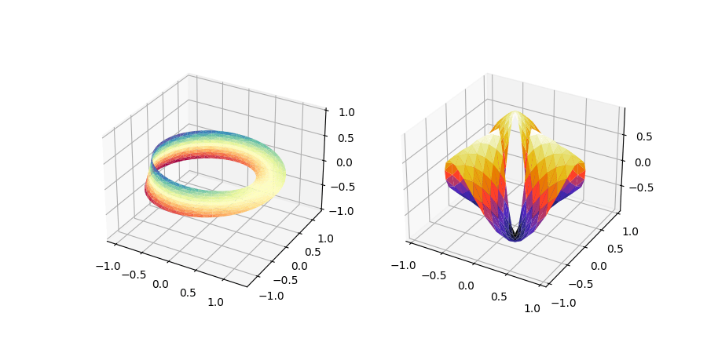

**plot_wireframe(*X*, *Y*, *Z*, *args, **kwargs)[[source]](https://github.com/matplotlib/matplotlib/blob/v3.5.1/lib/matplotlib/_api/deprecation.py#L1793-L1910)**

Plot a 3D wireframe.

Note

The *rcount* and *ccount* kwargs, which both default to 50, determine the maximum number of samples used in each direction. If the input data is larger, it will be downsampled (by slicing) to these numbers of points.

**Parameters**

**X, Y, Z**2D arrays**

Data values.

**rcount, ccount**int**

Maximum number of samples used in each direction. If the input data is larger, it will be downsampled (by slicing) to these numbers of points. Setting a count to zero causes the data to be not sampled in the corresponding direction, producing a 3D line plot rather than a wireframe plot. Defaults to 50.

**rstride, cstride**int**

Downsampling stride in each direction. These arguments are mutually exclusive with *rcount* and *ccount*. If only one of *rstride* or *cstride* is set, the other defaults to 1. Setting a stride to zero causes the data to be not sampled in the corresponding direction, producing a 3D line plot rather than a wireframe plot.

'classic' mode uses a default of `rstride = cstride = 1` instead of the new default of `rcount = ccount = 50`.

**kwargs**

Other arguments are forwarded to `Line3DCollection`.

**quiver(*X*, *Y*, *Z*, *U*, *V*, *W*, */*, *length=1*, *arrow_length_ratio=.3*, *pivot='tail'*, *normalize=False*, **kwargs)[[source]](https://github.com/matplotlib/matplotlib/blob/v3.5.1/lib/mpl_toolkits/mplot3d/axes3d.py#L2629-L2778)**

Plot a 3D field of arrows.

The arguments could be array-like or scalars, so long as they they can be broadcast together. The arguments can also be masked arrays. If an element in any of argument is masked, then that corresponding quiver element will not be plotted.

**Parameters**

**X, Y, Z**array-like**

The x, y and z coordinates of the arrow locations (default is tail of arrow; see *pivot* kwarg).

**U, V, W**array-like**

The x, y and z components of the arrow vectors.

**length**float, default: 1**

The length of each quiver.

**arrow_length_ratio**float, default: 0.3**

The ratio of the arrow head with respect to the quiver.

**pivot**{'tail', 'middle', 'tip'}, default: 'tail'**

The part of the arrow that is at the grid point; the arrow rotates about this point, hence the name *pivot*.

**normalize**bool, default: False**

Whether all arrows are normalized to have the same length, or keep the lengths defined by *u*, *v*, and *w*.

**data**indexable object, optional**

If given, all parameters also accept a string `s`, which is interpreted as `data[s]` (unless this raises an exception).

**kwargs**

Any additional keyword arguments are delegated to `LineCollection`

**quiver3D(*X*, *Y*, *Z*, *U*, *V*, *W*, */*, *length=1*, *arrow_length_ratio=.3*, *pivot='tail'*, *normalize=False*, **kwargs)[[source]](https://github.com/matplotlib/matplotlib/blob/v3.5.1/lib/mpl_toolkits/mplot3d/axes3d.py#L2629-L2778)**

Plot a 3D field of arrows.

The arguments could be array-like or scalars, so long as they they can be broadcast together. The arguments can also be masked arrays. If an element in any of argument is masked, then that corresponding quiver element will not be plotted.

**Parameters**

**X, Y, Z**array-like**

The x, y and z coordinates of the arrow locations (default is tail of arrow; see *pivot* kwarg).

**U, V, W**array-like**

The x, y and z components of the arrow vectors.

**length**float, default: 1**

The length of each quiver.

**arrow_length_ratio**float, default: 0.3**

The ratio of the arrow head with respect to the quiver.

**pivot**{'tail', 'middle', 'tip'}, default: 'tail'**

The part of the arrow that is at the grid point; the arrow rotates about this point, hence the name *pivot*.

**normalize**bool, default: False**

Whether all arrows are normalized to have the same length, or keep the lengths defined by *u*, *v*, and *w*.

**data**indexable object, optional**

If given, all parameters also accept a string `s`, which is interpreted as `data[s]` (unless this raises an exception).

**kwargs**

Any additional keyword arguments are delegated to `LineCollection`

**scatter(*xs*, *ys*, *zs=0*, *zdir='z'*, *s=20*, *c=None*, *depthshade=True*, *args, *data=None*, **kwargs)[[source]](https://github.com/matplotlib/matplotlib/blob/v3.5.1/lib/mpl_toolkits/mplot3d/axes3d.py#L2326-L2398)**

Create a scatter plot.

**Parameters**

**xs, ys**array-like**

The data positions.

**zs**float or array-like, default: 0**

The z-positions. Either an array of the same length as *xs* and *ys* or a single value to place all points in the same plane.

**zdir**{'x', 'y', 'z', '-x', '-y', '-z'}, default: 'z'**

The axis direction for the *zs*. This is useful when plotting 2D data on a 3D Axes. The data must be passed as *xs*, *ys*. Setting *zdir* to 'y' then plots the data to the x-z-plane.

See also [Plot 2D data on 3D plot](https://matplotlib.org/3.5.1/gallery/mplot3d/2dcollections3d.html).

**s**float or array-like, default: 20**

The marker size in points**2. Either an array of the same length as *xs* and *ys* or a single value to make all markers the same size.

**c**color, sequence, or sequence of colors, optional**

The marker color. Possible values:

- A single color format string.
- A sequence of colors of length n.
- A sequence of n numbers to be mapped to colors using *cmap* and *norm*.
- A 2D array in which the rows are RGB or RGBA.

For more details see the *c* argument of `scatter`.

**depthshade**bool, default: True**

Whether to shade the scatter markers to give the appearance of depth. Each call to `scatter()` will perform its depthshading independently.

**data**indexable object, optional**

If given, the following parameters also accept a string `s`, which is interpreted as `data[s]` (unless this raises an exception):

*xs*, *ys*, *zs*, *s*, *edgecolors*, *c*, *facecolor*, *facecolors*, *color*

**kwargs**

All other arguments are passed on to `scatter`.

**Returns**

**paths**`PathCollection`**

**scatter3D(*xs*, *ys*, *zs=0*, *zdir='z'*, *s=20*, *c=None*, *depthshade=True*, *args, *data=None*, **kwargs)[[source]](https://github.com/matplotlib/matplotlib/blob/v3.5.1/lib/mpl_toolkits/mplot3d/axes3d.py#L2326-L2398)**

Create a scatter plot.

**Parameters**

**xs, ys**array-like**

The data positions.

**zs**float or array-like, default: 0**

The z-positions. Either an array of the same length as *xs* and *ys* or a single value to place all points in the same plane.

**zdir**{'x', 'y', 'z', '-x', '-y', '-z'}, default: 'z'**

The axis direction for the *zs*. This is useful when plotting 2D data on a 3D Axes. The data must be passed as *xs*, *ys*. Setting *zdir* to 'y' then plots the data to the x-z-plane.

See also [Plot 2D data on 3D plot](https://matplotlib.org/3.5.1/gallery/mplot3d/2dcollections3d.html).

**s**float or array-like, default: 20**

The marker size in points**2. Either an array of the same length as *xs* and *ys* or a single value to make all markers the same size.

**c**color, sequence, or sequence of colors, optional**

The marker color. Possible values:

- A single color format string.
- A sequence of colors of length n.
- A sequence of n numbers to be mapped to colors using *cmap* and *norm*.
- A 2D array in which the rows are RGB or RGBA.

For more details see the *c* argument of `scatter`.

**depthshade**bool, default: True**

Whether to shade the scatter markers to give the appearance of depth. Each call to `scatter()` will perform its depthshading independently.

**data**indexable object, optional**

If given, the following parameters also accept a string `s`, which is interpreted as `data[s]` (unless this raises an exception):

*xs*, *ys*, *zs*, *s*, *edgecolors*, *c*, *facecolor*, *facecolors*, *color*

**kwargs**

All other arguments are passed on to `scatter`.

**Returns**

**paths**`PathCollection`**

**set(*, *adjustable=<UNSET>*, *agg_filter=<UNSET>*, *alpha=<UNSET>*, *anchor=<UNSET>*, *animated=<UNSET>*, *aspect=<UNSET>*, *autoscale_on=<UNSET>*, *autoscalex_on=<UNSET>*, *autoscaley_on=<UNSET>*, *autoscalez_on=<UNSET>*, *axes_locator=<UNSET>*, *axisbelow=<UNSET>*, *box_aspect=<UNSET>*, *clip_box=<UNSET>*, *clip_on=<UNSET>*, *clip_path=<UNSET>*, *facecolor=<UNSET>*, *frame_on=<UNSET>*, *gid=<UNSET>*, *in_layout=<UNSET>*, *label=<UNSET>*, *navigate=<UNSET>*, *path_effects=<UNSET>*, *picker=<UNSET>*, *position=<UNSET>*, *proj_type=<UNSET>*, *prop_cycle=<UNSET>*, *rasterization_zorder=<UNSET>*, *rasterized=<UNSET>*, *sketch_params=<UNSET>*, *snap=<UNSET>*, *title=<UNSET>*, *transform=<UNSET>*, *url=<UNSET>*, *visible=<UNSET>*, *xbound=<UNSET>*, *xlabel=<UNSET>*, *xlim=<UNSET>*, *xlim3d=<UNSET>*, *xmargin=<UNSET>*, *xscale=<UNSET>*, *xticklabels=<UNSET>*, *xticks=<UNSET>*, *ybound=<UNSET>*, *ylabel=<UNSET>*, *ylim=<UNSET>*, *ylim3d=<UNSET>*, *ymargin=<UNSET>*, *yscale=<UNSET>*, *yticklabels=<UNSET>*, *yticks=<UNSET>*, *zbound=<UNSET>*, *zlabel=<UNSET>*, *zlim3d=<UNSET>*, *zmargin=<UNSET>*, *zorder=<UNSET>*, *zscale=<UNSET>*, *zticklabels=<UNSET>*, *zticks=<UNSET>*)[[source]](https://github.com/matplotlib/matplotlib/blob/v3.5.1/lib/matplotlib/artist.py#L116-L116)**

Set multiple properties at once.

Supported properties are

| Property | Description |
| --- | --- |
| `adjustable` | {'box', 'datalim'} |
| `agg_filter` | a filter function, which takes a (m, n, 3) float array and a dpi value, and returns a (m, n, 3) array |
| `alpha` | scalar or None |
| `anchor` | (float, float) or {'C', 'SW', 'S', 'SE', 'E', 'NE', ...} |
| `animated` | bool |
| `aspect` | {'auto'} |
| `autoscale_on` | unknown |
| `autoscalex_on` | bool |
| `autoscaley_on` | bool |
| `autoscalez_on` | bool |
| `axes_locator` | Callable[[Axes, Renderer], Bbox] |
| `axisbelow` | bool or 'line' |
| `box_aspect` | 3-tuple of floats or None |
| `clip_box` | `Bbox` |
| `clip_on` | bool |
| `clip_path` | Patch or (Path, Transform) or None |
| `facecolor` or fc | color |
| `figure` | `Figure` |
| `frame_on` | bool |
| `gid` | str |
| `in_layout` | bool |
| `label` | object |
| `navigate` | bool |
| `navigate_mode` | unknown |
| `path_effects` | `AbstractPathEffect` |
| `picker` | None or bool or float or callable |
| `position` | [left, bottom, width, height] or `Bbox` |
| `proj_type` | {'persp', 'ortho'} |
| `prop_cycle` | unknown |
| `rasterization_zorder` | float or None |
| `rasterized` | bool |
| `sketch_params` | (scale: float, length: float, randomness: float) |
| `snap` | bool or None |
| `title` | unknown |
| `transform` | `Transform` |
| `url` | str |
| `visible` | bool |
| `xbound` | unknown |
| `xlabel` | str |
| `xlim` | (bottom: float, top: float) |
| `xlim3d` | unknown |
| `xmargin` | unknown |
| `xscale` | {"linear"} |
| `xticklabels` | unknown |
| `xticks` | unknown |
| `ybound` | unknown |
| `ylabel` | str |
| `ylim` | (bottom: float, top: float) |
| `ylim3d` | unknown |
| `ymargin` | unknown |
| `yscale` | {"linear"} |
| `yticklabels` | unknown |
| `yticks` | unknown |
| `zbound` | unknown |
| `zlabel` | unknown |
| `zlim3d` | unknown |
| `zmargin` | unknown |
| `zorder` | float |
| `zscale` | {"linear"} |
| `zticklabels` | unknown |
| `zticks` | unknown |

**set_aspect(*aspect*, *adjustable=None*, *anchor=None*, *share=False*)[[source]](https://github.com/matplotlib/matplotlib/blob/v3.5.1/lib/mpl_toolkits/mplot3d/axes3d.py#L257-L316)**

Set the aspect ratios.

Axes 3D does not current support any aspect but 'auto' which fills the axes with the data limits.

To simulate having equal aspect in data space, set the ratio of your data limits to match the value of `get_box_aspect`. To control box aspect ratios use `set_box_aspect`.

**Parameters**

**aspect**{'auto'}**

Possible values:

| value | description |
| --- | --- |
| 'auto' | automatic; fill the position rectangle with data. |

**adjustable**None**

Currently ignored by Axes3D

If not *None*, this defines which parameter will be adjusted to meet the required aspect. See `set_adjustable` for further details.

**anchor**None or str or 2-tuple of float, optional**

If not *None*, this defines where the Axes will be drawn if there is extra space due to aspect constraints. The most common way to to specify the anchor are abbreviations of cardinal directions:

| value | description |
| --- | --- |
| 'C' | centered |
| 'SW' | lower left corner |
| 'S' | middle of bottom edge |
| 'SE' | lower right corner |
| etc. |  |

See `set_anchor` for further details.

**share**bool, default: False**

If `True`, apply the settings to all shared Axes.

See also

**`mpl_toolkits.mplot3d.axes3d.Axes3D.set_box_aspect`**

**set_autoscale_on(*b*)[[source]](https://github.com/matplotlib/matplotlib/blob/v3.5.1/lib/mpl_toolkits/mplot3d/axes3d.py#L505-L508)**

Set whether autoscaling is applied to each axis on the next draw or call to `Axes.autoscale_view`.

**Parameters**

**b**bool**

**set_autoscalez_on(*b*)[[source]](https://github.com/matplotlib/matplotlib/blob/v3.5.1/lib/mpl_toolkits/mplot3d/axes3d.py#L510-L519)**

Set whether the z-axis is autoscaled on the next draw or call to `Axes.autoscale_view`.

**Parameters**

**b**bool**

**set_axis_off()[[source]](https://github.com/matplotlib/matplotlib/blob/v3.5.1/lib/mpl_toolkits/mplot3d/axes3d.py#L169-L171)**

Turn the x- and y-axis off.

This affects the axis lines, ticks, ticklabels, grid and axis labels.

**set_axis_on()[[source]](https://github.com/matplotlib/matplotlib/blob/v3.5.1/lib/mpl_toolkits/mplot3d/axes3d.py#L173-L175)**

Turn the x- and y-axis on.

This affects the axis lines, ticks, ticklabels, grid and axis labels.

**set_box_aspect(*aspect*, *, *zoom=1*)[[source]](https://github.com/matplotlib/matplotlib/blob/v3.5.1/lib/mpl_toolkits/mplot3d/axes3d.py#L318-L358)**

Set the axes box aspect.

The box aspect is the ratio of height to width in display units for each face of the box when viewed perpendicular to that face. This is not to be confused with the data aspect (which for Axes3D is always 'auto'). The default ratios are 4:4:3 (x:y:z).

To simulate having equal aspect in data space, set the box aspect to match your data range in each dimension.

*zoom* controls the overall size of the Axes3D in the figure.

**Parameters**

**aspect**3-tuple of floats or None**

Changes the physical dimensions of the Axes3D, such that the ratio of the axis lengths in display units is x:y:z.

If None, defaults to 4:4:3

**zoom**float**

Control overall size of the Axes3D in the figure.

**set_frame_on(*b*)[[source]](https://github.com/matplotlib/matplotlib/blob/v3.5.1/lib/mpl_toolkits/mplot3d/axes3d.py#L1322-L1331)**

Set whether the 3D axes panels are drawn.

**Parameters**

**b**bool**

**set_proj_type(*proj_type*)[[source]](https://github.com/matplotlib/matplotlib/blob/v3.5.1/lib/mpl_toolkits/mplot3d/axes3d.py#L1019-L1030)**

Set the projection type.

**Parameters**

**proj_type**{'persp', 'ortho'}**

**set_title(*label*, *fontdict=None*, *loc='center'*, **kwargs)[[source]](https://github.com/matplotlib/matplotlib/blob/v3.5.1/lib/mpl_toolkits/mplot3d/axes3d.py#L2622-L2627)**

Set a title for the Axes.

Set one of the three available Axes titles. The available titles are positioned above the Axes in the center, flush with the left edge, and flush with the right edge.

**Parameters**

**label**str**

Text to use for the title

**fontdict**dict**

A dictionary controlling the appearance of the title text, the default *fontdict* is:

```
{'fontsize': rcParams['axes.titlesize'],
 'fontweight': rcParams['axes.titleweight'],
 'color': rcParams['axes.titlecolor'],
 'verticalalignment': 'baseline',
 'horizontalalignment': loc}
```

**loc**{'center', 'left', 'right'}, default: `rcParams["axes.titlelocation"]` (default: `'center'`)**

Which title to set.

**y**float, default: `rcParams["axes.titley"]` (default: `None`)**

Vertical Axes loation for the title (1.0 is the top). If None (the default), y is determined automatically to avoid decorators on the Axes.

**pad**float, default: `rcParams["axes.titlepad"]` (default: `6.0`)**

The offset of the title from the top of the Axes, in points.

**Returns**

**`Text`**

The matplotlib text instance representing the title

**Other Parameters**

**kwargs`Text` properties**

Other keyword arguments are text properties, see `Text` for a list of valid text properties.

**set_top_view()[[source]](https://github.com/matplotlib/matplotlib/blob/v3.5.1/lib/mpl_toolkits/mplot3d/axes3d.py#L184-L194)**

**set_xlim(*left=None*, *right=None*, *emit=True*, *auto=False*, *, *xmin=None*, *xmax=None*)[[source]](https://github.com/matplotlib/matplotlib/blob/v3.5.1/lib/mpl_toolkits/mplot3d/axes3d.py#L731-L786)**

Alias for `set_xlim3d`.

**set_xlim3d(*left=None*, *right=None*, *emit=True*, *auto=False*, *, *xmin=None*, *xmax=None*)[[source]](https://github.com/matplotlib/matplotlib/blob/v3.5.1/lib/mpl_toolkits/mplot3d/axes3d.py#L731-L786)**

Set 3D x limits.

See `matplotlib.axes.Axes.set_xlim()` for full documentation.

**set_xmargin(*m*)[[source]](https://github.com/matplotlib/matplotlib/blob/v3.5.1/lib/mpl_toolkits/mplot3d/axes3d.py#L521-L528)**

Set padding of X data limits prior to autoscaling.

*m* times the data interval will be added to each end of that interval before it is used in autoscaling. For example, if your data is in the range [0, 2], a factor of `m = 0.1` will result in a range [-0.2, 2.2].

Negative values -0.5 < m < 0 will result in clipping of the data range. I.e. for a data range [0, 2], a factor of `m = -0.1` will result in a range [0.2, 1.8].

**Parameters**

**m**float greater than -0.5**

**set_xscale(*value*, **kwargs)[[source]](https://github.com/matplotlib/matplotlib/blob/v3.5.1/lib/mpl_toolkits/mplot3d/axes3d.py#L926-L930)**

Set the x-axis scale.

**Parameters**

**value**{"linear"}**

The axis scale type to apply. 3D axes currently only support linear scales; other scales yield nonsensical results.

**kwargs**

Keyword arguments are nominally forwarded to the scale class, but none of them is applicable for linear scales.

**set_ylim(*bottom=None*, *top=None*, *emit=True*, *auto=False*, *, *ymin=None*, *ymax=None*)[[source]](https://github.com/matplotlib/matplotlib/blob/v3.5.1/lib/mpl_toolkits/mplot3d/axes3d.py#L788-L844)**

Alias for `set_ylim3d`.

**set_ylim3d(*bottom=None*, *top=None*, *emit=True*, *auto=False*, *, *ymin=None*, *ymax=None*)[[source]](https://github.com/matplotlib/matplotlib/blob/v3.5.1/lib/mpl_toolkits/mplot3d/axes3d.py#L788-L844)**

Set 3D y limits.

See `matplotlib.axes.Axes.set_ylim()` for full documentation.

**set_ymargin(*m*)[[source]](https://github.com/matplotlib/matplotlib/blob/v3.5.1/lib/mpl_toolkits/mplot3d/axes3d.py#L530-L537)**

Set padding of Y data limits prior to autoscaling.

*m* times the data interval will be added to each end of that interval before it is used in autoscaling. For example, if your data is in the range [0, 2], a factor of `m = 0.1` will result in a range [-0.2, 2.2].

Negative values -0.5 < m < 0 will result in clipping of the data range. I.e. for a data range [0, 2], a factor of `m = -0.1` will result in a range [0.2, 1.8].

**Parameters**

**m**float greater than -0.5**

**set_yscale(*value*, **kwargs)[[source]](https://github.com/matplotlib/matplotlib/blob/v3.5.1/lib/mpl_toolkits/mplot3d/axes3d.py#L932-L936)**

Set the y-axis scale.

**Parameters**

**value**{"linear"}**

The axis scale type to apply. 3D axes currently only support linear scales; other scales yield nonsensical results.

**kwargs**

Keyword arguments are nominally forwarded to the scale class, but none of them is applicable for linear scales.

**set_zbound(*lower=None*, *upper=None*)[[source]](https://github.com/matplotlib/matplotlib/blob/v3.5.1/lib/mpl_toolkits/mplot3d/axes3d.py#L1431-L1449)**

Set the lower and upper numerical bounds of the z-axis.

This method will honor axes inversion regardless of parameter order. It will not change the autoscaling setting (`get_autoscalez_on()`).

**set_zlabel(*zlabel*, *fontdict=None*, *labelpad=None*, **kwargs)[[source]](https://github.com/matplotlib/matplotlib/blob/v3.5.1/lib/mpl_toolkits/mplot3d/axes3d.py#L1301-L1307)**

Set zlabel. See doc for `set_ylabel` for description.

**set_zlim(*bottom=None*, *top=None*, *emit=True*, *auto=False*, *, *zmin=None*, *zmax=None*)[[source]](https://github.com/matplotlib/matplotlib/blob/v3.5.1/lib/mpl_toolkits/mplot3d/axes3d.py#L846-L902)**

Alias for `set_zlim3d`.

**set_zlim3d(*bottom=None*, *top=None*, *emit=True*, *auto=False*, *, *zmin=None*, *zmax=None*)[[source]](https://github.com/matplotlib/matplotlib/blob/v3.5.1/lib/mpl_toolkits/mplot3d/axes3d.py#L846-L902)**

Set 3D z limits.

See `matplotlib.axes.Axes.set_ylim()` for full documentation

**set_zmargin(*m*)[[source]](https://github.com/matplotlib/matplotlib/blob/v3.5.1/lib/mpl_toolkits/mplot3d/axes3d.py#L539-L552)**

Set padding of Z data limits prior to autoscaling.

*m* times the data interval will be added to each end of that interval before it is used in autoscaling.

accepts: float in range 0 to 1

**set_zscale(*value*, **kwargs)[[source]](https://github.com/matplotlib/matplotlib/blob/v3.5.1/lib/mpl_toolkits/mplot3d/axes3d.py#L938-L942)**

Set the z-axis scale.

**Parameters**

**value**{"linear"}**

The axis scale type to apply. 3D axes currently only support linear scales; other scales yield nonsensical results.

**kwargs**

Keyword arguments are nominally forwarded to the scale class, but none of them is applicable for linear scales.

**set_zticklabels(*labels*, *, *fontdict=None*, *minor=False*, **kwargs)[[source]](https://github.com/matplotlib/matplotlib/blob/v3.5.1/lib/matplotlib/axes/_base.py#L74-L75)**

Set the zaxis' labels with list of string labels.

Warning

This method should only be used after fixing the tick positions using `Axes3D.set_zticks`. Otherwise, the labels may end up in unexpected positions.

**Parameters**

**labels**list of str**

The label texts.

**fontdict**dict, optional**

A dictionary controlling the appearance of the ticklabels. The default *fontdict* is:

```
{'fontsize': rcParams['axes.titlesize'],
 'fontweight': rcParams['axes.titleweight'],
 'verticalalignment': 'baseline',
 'horizontalalignment': loc}
```

**minor**bool, default: False**

Whether to set the minor ticklabels rather than the major ones.

**Returns**

**list of `Text`**

The labels.

**Other Parameters**

**kwargs`Text` properties.**

**set_zticks(*ticks*, *labels=None*, *, *minor=False*, **kwargs)[[source]](https://github.com/matplotlib/matplotlib/blob/v3.5.1/lib/matplotlib/axes/_base.py#L74-L75)**

Set the zaxis' tick locations and optionally labels.

If necessary, the view limits of the Axis are expanded so that all given ticks are visible.

**Parameters**

**ticks**list of floats**

List of tick locations.

**labels**list of str, optional**

List of tick labels. If not set, the labels show the data value.

**minor**bool, default: False**

If `False`, set the major ticks; if `True`, the minor ticks.

**kwargs**

`Text` properties for the labels. These take effect only if you pass *labels*. In other cases, please use `tick_params`.

#### Notes

The mandatory expansion of the view limits is an intentional design choice to prevent the surprise of a non-visible tick. If you need other limits, you should set the limits explicitly after setting the ticks.

**stem(*x*, *y*, *z*, *, *linefmt='C0-'*, *markerfmt='C0o'*, *basefmt='C3-'*, *bottom=0*, *label=None*, *orientation='z'*, *data=None*)[[source]](https://github.com/matplotlib/matplotlib/blob/v3.5.1/lib/mpl_toolkits/mplot3d/axes3d.py#L3373-L3488)**

Create a 3D stem plot.

A stem plot draws lines perpendicular to a baseline, and places markers at the heads. By default, the baseline is defined by *x* and *y*, and stems are drawn vertically from *bottom* to *z*.

**Parameters**

**x, y, z**array-like**

The positions of the heads of the stems. The stems are drawn along the *orientation*-direction from the baseline at *bottom* (in the *orientation*-coordinate) to the heads. By default, the *x* and *y* positions are used for the baseline and *z* for the head position, but this can be changed by *orientation*.

**linefmt**str, default: 'C0-'**

A string defining the properties of the vertical lines. Usually, this will be a color or a color and a linestyle:

| Character | Line Style |
| --- | --- |
| `'-'` | solid line |
| `'--'` | dashed line |
| `'-.'` | dash-dot line |
| `':'` | dotted line |

Note: While it is technically possible to specify valid formats other than color or color and linestyle (e.g. 'rx' or '-.'), this is beyond the intention of the method and will most likely not result in a reasonable plot.

**markerfmt**str, default: 'C0o'**

A string defining the properties of the markers at the stem heads.

**basefmt**str, default: 'C3-'**

A format string defining the properties of the baseline.

**bottom**float, default: 0**

The position of the baseline, in *orientation*-coordinates.

**label**str, default: None**

The label to use for the stems in legends.

**orientation**{'x', 'y', 'z'}, default: 'z'**

The direction along which stems are drawn.

**data**indexable object, optional**

If given, all parameters also accept a string `s`, which is interpreted as `data[s]` (unless this raises an exception).

**Returns**

**`StemContainer`**

The container may be treated like a tuple (*markerline*, *stemlines*, *baseline*)

#### Examples

([Source code](https://matplotlib.org/3.5.1/gallery/mplot3d/stem3d_demo.py), png, pdf)

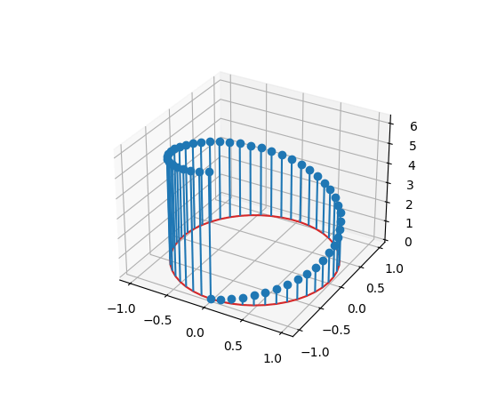

(png, pdf)

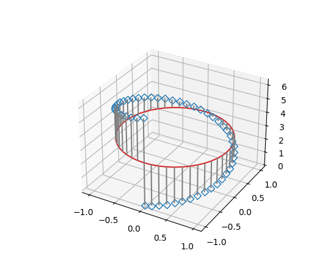

(png, pdf)

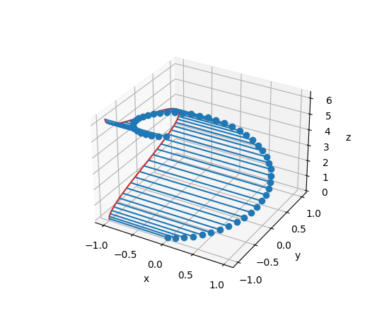

**stem3D(*x*, *y*, *z*, *, *linefmt='C0-'*, *markerfmt='C0o'*, *basefmt='C3-'*, *bottom=0*, *label=None*, *orientation='z'*, *data=None*)[[source]](https://github.com/matplotlib/matplotlib/blob/v3.5.1/lib/mpl_toolkits/mplot3d/axes3d.py#L3373-L3488)**

Create a 3D stem plot.

A stem plot draws lines perpendicular to a baseline, and places markers at the heads. By default, the baseline is defined by *x* and *y*, and stems are drawn vertically from *bottom* to *z*.

**Parameters**

**x, y, z**array-like**

The positions of the heads of the stems. The stems are drawn along the *orientation*-direction from the baseline at *bottom* (in the *orientation*-coordinate) to the heads. By default, the *x* and *y* positions are used for the baseline and *z* for the head position, but this can be changed by *orientation*.

**linefmt**str, default: 'C0-'**

A string defining the properties of the vertical lines. Usually, this will be a color or a color and a linestyle:

| Character | Line Style |
| --- | --- |
| `'-'` | solid line |
| `'--'` | dashed line |
| `'-.'` | dash-dot line |
| `':'` | dotted line |

Note: While it is technically possible to specify valid formats other than color or color and linestyle (e.g. 'rx' or '-.'), this is beyond the intention of the method and will most likely not result in a reasonable plot.

**markerfmt**str, default: 'C0o'**

A string defining the properties of the markers at the stem heads.

**basefmt**str, default: 'C3-'**

A format string defining the properties of the baseline.

**bottom**float, default: 0**

The position of the baseline, in *orientation*-coordinates.

**label**str, default: None**

The label to use for the stems in legends.

**orientation**{'x', 'y', 'z'}, default: 'z'**

The direction along which stems are drawn.

**data**indexable object, optional**

If given, all parameters also accept a string `s`, which is interpreted as `data[s]` (unless this raises an exception).

**Returns**

**`StemContainer`**

The container may be treated like a tuple (*markerline*, *stemlines*, *baseline*)

#### Examples

([Source code](https://matplotlib.org/3.5.1/gallery/mplot3d/stem3d_demo.py), png, pdf)

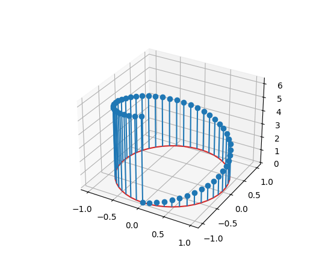

(png, pdf)

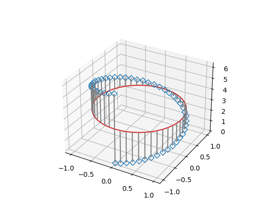

(png, pdf)

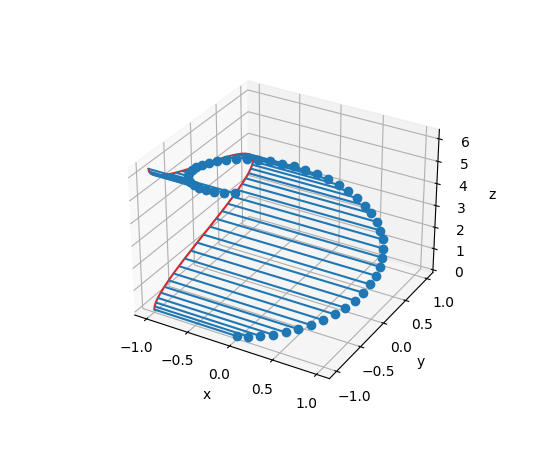

**text(*x*, *y*, *z*, *s*, *zdir=None*, **kwargs)[[source]](https://github.com/matplotlib/matplotlib/blob/v3.5.1/lib/mpl_toolkits/mplot3d/axes3d.py#L1451-L1459)**

Add text to the plot. kwargs will be passed on to Axes.text, except for the *zdir* keyword, which sets the direction to be used as the z direction.

**text2D(*x*, *y*, *s*, *fontdict=None*, **kwargs)[[source]](https://github.com/matplotlib/matplotlib/blob/v3.5.1/lib/matplotlib/axes/_axes.py#L596-L662)**

Add text to the Axes.

Add the text *s* to the Axes at location *x*, *y* in data coordinates.

**Parameters**

**x, y**float**

The position to place the text. By default, this is in data coordinates. The coordinate system can be changed using the *transform* parameter.

**s**str**

The text.

**fontdict**dict, default: None**

A dictionary to override the default text properties. If fontdict is None, the defaults are determined by `rcParams`.

**Returns**

**`Text`**

The created `Text` instance.

**Other Parameters**

**kwargs`Text` properties.**

Other miscellaneous text parameters.

| Property | Description |
| --- | --- |
| `agg_filter` | a filter function, which takes a (m, n, 3) float array and a dpi value, and returns a (m, n, 3) array |
| `alpha` | scalar or None |
| `animated` | bool |
| `backgroundcolor` | color |
| `bbox` | dict with properties for `patches.FancyBboxPatch` |
| `clip_box` | unknown |
| `clip_on` | unknown |
| `clip_path` | unknown |
| `color` or c | color |
| `figure` | `Figure` |
| `fontfamily` or family | {FONTNAME, 'serif', 'sans-serif', 'cursive', 'fantasy', 'monospace'} |
| `fontproperties` or font or font_properties | `font_manager.FontProperties` or [`str`](https://docs.python.org/3/library/stdtypes.html#str) or [`pathlib.Path`](https://docs.python.org/3/library/pathlib.html#pathlib.Path) |
| `fontsize` or size | float or {'xx-small', 'x-small', 'small', 'medium', 'large', 'x-large', 'xx-large'} |
| `fontstretch` or stretch | {a numeric value in range 0-1000, 'ultra-condensed', 'extra-condensed', 'condensed', 'semi-condensed', 'normal', 'semi-expanded', 'expanded', 'extra-expanded', 'ultra-expanded'} |
| `fontstyle` or style | {'normal', 'italic', 'oblique'} |
| `fontvariant` or variant | {'normal', 'small-caps'} |
| `fontweight` or weight | {a numeric value in range 0-1000, 'ultralight', 'light', 'normal', 'regular', 'book', 'medium', 'roman', 'semibold', 'demibold', 'demi', 'bold', 'heavy', 'extra bold', 'black'} |
| `gid` | str |
| `horizontalalignment` or ha | {'center', 'right', 'left'} |
| `in_layout` | bool |
| `label` | object |
| `linespacing` | float (multiple of font size) |
| `math_fontfamily` | str |
| `multialignment` or ma | {'left', 'right', 'center'} |
| `parse_math` | bool |
| `path_effects` | `AbstractPathEffect` |
| `picker` | None or bool or float or callable |
| `position` | (float, float) |
| `rasterized` | bool |
| `rotation` | float or {'vertical', 'horizontal'} |
| `rotation_mode` | {None, 'default', 'anchor'} |
| `sketch_params` | (scale: float, length: float, randomness: float) |
| `snap` | bool or None |
| `text` | object |
| `transform` | `Transform` |
| `transform_rotates_text` | bool |
| `url` | str |
| `usetex` | bool or None |
| `verticalalignment` or va | {'center', 'top', 'bottom', 'baseline', 'center_baseline'} |
| `visible` | bool |
| `wrap` | bool |
| `x` | float |
| `y` | float |
| `zorder` | float |

#### Examples

Individual keyword arguments can be used to override any given parameter:

```
>>> text(x, y, s, fontsize=12)
```

The default transform specifies that text is in data coords, alternatively, you can specify text in axis coords ((0, 0) is lower-left and (1, 1) is upper-right). The example below places text in the center of the Axes:

```
>>> text(0.5, 0.5, 'matplotlib', horizontalalignment='center',
...      verticalalignment='center', transform=ax.transAxes)
```

You can put a rectangular box around the text instance (e.g., to set a background color) by using the keyword *bbox*. *bbox* is a dictionary of `Rectangle` properties. For example:

```
>>> text(x, y, s, bbox=dict(facecolor='red', alpha=0.5))
```

**text3D(*x*, *y*, *z*, *s*, *zdir=None*, **kwargs)[[source]](https://github.com/matplotlib/matplotlib/blob/v3.5.1/lib/mpl_toolkits/mplot3d/axes3d.py#L1451-L1459)**

Add text to the plot. kwargs will be passed on to Axes.text, except for the *zdir* keyword, which sets the direction to be used as the z direction.

**tick_params(*axis='both'*, **kwargs)[[source]](https://github.com/matplotlib/matplotlib/blob/v3.5.1/lib/mpl_toolkits/mplot3d/axes3d.py#L1373-L1403)**

Convenience method for changing the appearance of ticks and tick labels.

See `matplotlib.axes.Axes.tick_params()` for more complete documentation.

The only difference is that setting *axis* to 'both' will mean that the settings are applied to all three axes. Also, the *axis* parameter also accepts a value of 'z', which would mean to apply to only the z-axis.

Also, because of how Axes3D objects are drawn very differently from regular 2D axes, some of these settings may have ambiguous meaning. For simplicity, the 'z' axis will accept settings as if it was like the 'y' axis.

Note

Axes3D currently ignores some of these settings.

**tricontour(*args, *extend3d=False*, *stride=5*, *zdir='z'*, *offset=None*, *data=None*, **kwargs)[[source]](https://github.com/matplotlib/matplotlib/blob/v3.5.1/lib/mpl_toolkits/mplot3d/axes3d.py#L2144-L2196)**

Create a 3D contour plot.

Note

This method currently produces incorrect output due to a longstanding bug in 3D PolyCollection rendering.

**Parameters**

**X, Y, Z**array-like**

Input data. See `tricontour` for acceptable data shapes.

**extend3d**bool, default: False**

Whether to extend contour in 3D.

**stride**int**

Step size for extending contour.

**zdir**{'x', 'y', 'z'}, default: 'z'**

The direction to use.

**offset**float, optional**

If specified, plot a projection of the contour lines at this position in a plane normal to zdir.

**data**indexable object, optional**

If given, all parameters also accept a string `s`, which is interpreted as `data[s]` (unless this raises an exception).

**args, **kwargs**

Other arguments are forwarded to `matplotlib.axes.Axes.tricontour`.

**Returns**

**matplotlib.tri.tricontour.TriContourSet**

**tricontourf(*args, *zdir='z'*, *offset=None*, *data=None*, **kwargs)[[source]](https://github.com/matplotlib/matplotlib/blob/v3.5.1/lib/mpl_toolkits/mplot3d/axes3d.py#L2243-L2291)**

Create a 3D filled contour plot.

Note

This method currently produces incorrect output due to a longstanding bug in 3D PolyCollection rendering.

**Parameters**

**X, Y, Z**array-like**

Input data. See `tricontourf` for acceptable data shapes.

**zdir**{'x', 'y', 'z'}, default: 'z'**

The direction to use.

**offset**float, optional**

If specified, plot a projection of the contour lines at this position in a plane normal to zdir.

**data**indexable object, optional**

If given, all parameters also accept a string `s`, which is interpreted as `data[s]` (unless this raises an exception).

**args, **kwargs**

Other arguments are forwarded to `matplotlib.axes.Axes.tricontourf`.

**Returns**

**matplotlib.tri.tricontour.TriContourSet**

**tunit_cube(*vals=None*, *M=None*)[[source]](https://github.com/matplotlib/matplotlib/blob/v3.5.1/lib/mpl_toolkits/mplot3d/axes3d.py#L232-L237)**

**tunit_edges(*vals=None*, *M=None*)[[source]](https://github.com/matplotlib/matplotlib/blob/v3.5.1/lib/mpl_toolkits/mplot3d/axes3d.py#L239-L255)**

**unit_cube(*vals=None*)[[source]](https://github.com/matplotlib/matplotlib/blob/v3.5.1/lib/mpl_toolkits/mplot3d/axes3d.py#L221-L230)**

**update_datalim(*xys*, **kwargs)[[source]](https://github.com/matplotlib/matplotlib/blob/v3.5.1/lib/mpl_toolkits/mplot3d/axes3d.py#L494-L495)**

Extend the `dataLim` Bbox to include the given points.

If no data is set currently, the Bbox will ignore its limits and set the bound to be the bounds of the xydata (*xys*). Otherwise, it will compute the bounds of the union of its current data and the data in *xys*.

**Parameters**

**xys**2D array-like**

The points to include in the data limits Bbox. This can be either a list of (x, y) tuples or a Nx2 array.

**updatex, updatey**bool, default: True**

Whether to update the x/y limits.

**view_init(*elev=None*, *azim=None*, *vertical_axis='z'*)[[source]](https://github.com/matplotlib/matplotlib/blob/v3.5.1/lib/mpl_toolkits/mplot3d/axes3d.py#L983-L1017)**

Set the elevation and azimuth of the axes in degrees (not radians).

This can be used to rotate the axes programmatically.

**Parameters**

**elev**float, default: None**

The elevation angle in the vertical plane in degrees. If None then the initial value as specified in the `Axes3D` constructor is used.

**azim**float, default: None**

The azimuth angle in the horizontal plane in degrees. If None then the initial value as specified in the `Axes3D` constructor is used.

**vertical_axis**{"z", "x", "y"}, default: "z"**

The axis to align vertically. *azim* rotates about this axis.

**voxels([*x*, *y*, *z*, ]*/*, *filled*, *facecolors=None*, *edgecolors=None*, **kwargs)[[source]](https://github.com/matplotlib/matplotlib/blob/v3.5.1/lib/mpl_toolkits/mplot3d/axes3d.py#L2782-L2996)**

Plot a set of filled voxels

All voxels are plotted as 1x1x1 cubes on the axis, with `filled[0, 0, 0]` placed with its lower corner at the origin. Occluded faces are not plotted.

**Parameters**

**filled**3D np.array of bool**

A 3D array of values, with truthy values indicating which voxels to fill

**x, y, z**3D np.array, optional**

The coordinates of the corners of the voxels. This should broadcast to a shape one larger in every dimension than the shape of *filled*. These can be used to plot non-cubic voxels.

If not specified, defaults to increasing integers along each axis, like those returned by [`indices()`](https://numpy.org/doc/stable/reference/generated/numpy.indices.html#numpy.indices). As indicated by the `/` in the function signature, these arguments can only be passed positionally.

**facecolors, edgecolors**array-like, optional**

The color to draw the faces and edges of the voxels. Can only be passed as keyword arguments. These parameters can be:

- A single color value, to color all voxels the same color. This can be either a string, or a 1D rgb/rgba array
- `None`, the default, to use a single color for the faces, and the style default for the edges.
- A 3D ndarray of color names, with each item the color for the corresponding voxel. The size must match the voxels.
- A 4D ndarray of rgb/rgba data, with the components along the last axis.

**shade**bool, default: True**

Whether to shade the facecolors. Shading is always disabled when *cmap* is specified.

**lightsource**`LightSource`**

The lightsource to use when *shade* is True.

**kwargs**

Additional keyword arguments to pass onto `Poly3DCollection`.

**Returns**

**faces**dict**

A dictionary indexed by coordinate, where `faces[i, j, k]` is a `Poly3DCollection` of the faces drawn for the voxel `filled[i, j, k]`. If no faces were drawn for a given voxel, either because it was not asked to be drawn, or it is fully occluded, then `(i, j, k) not in faces`.

#### Examples

([Source code](https://matplotlib.org/3.5.1/gallery/mplot3d/voxels.py), png, pdf)

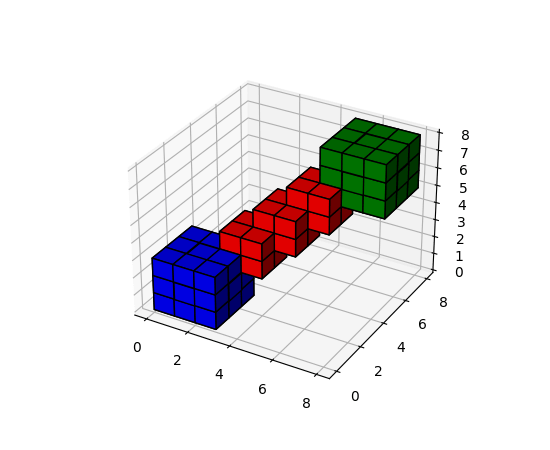

([Source code](https://matplotlib.org/3.5.1/gallery/mplot3d/voxels_rgb.py), png, pdf)

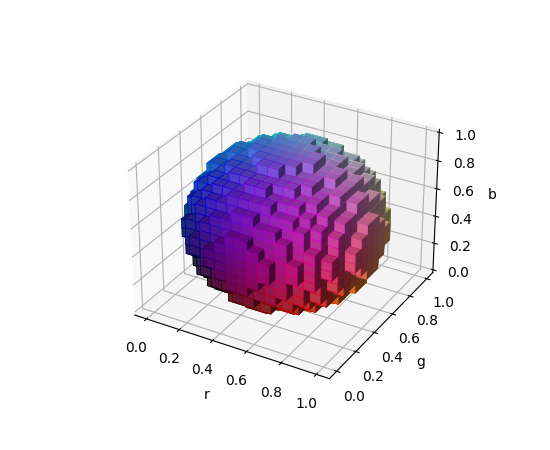

([Source code](https://matplotlib.org/3.5.1/gallery/mplot3d/voxels_torus.py), png, pdf)

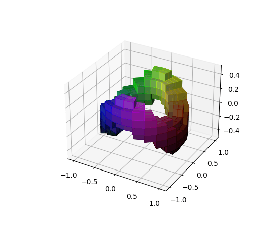

([Source code](https://matplotlib.org/3.5.1/gallery/mplot3d/voxels_numpy_logo.py), png, pdf)

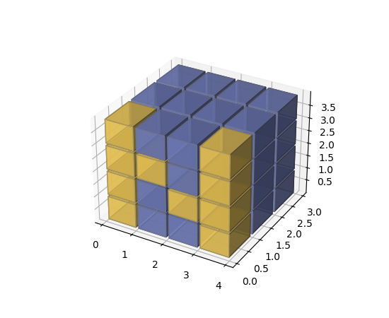

**property*w_xaxis[[source]](https://github.com/matplotlib/matplotlib/blob/v3.5.1/lib/matplotlib/_api/deprecation.py)**

**property*w_yaxis[[source]](https://github.com/matplotlib/matplotlib/blob/v3.5.1/lib/matplotlib/_api/deprecation.py)**

**property*w_zaxis[[source]](https://github.com/matplotlib/matplotlib/blob/v3.5.1/lib/matplotlib/_api/deprecation.py)**

**zaxis_date(*tz=None*)[[source]](https://github.com/matplotlib/matplotlib/blob/v3.5.1/lib/matplotlib/axes/_base.py#L74-L75)**

Set up axis ticks and labels to treat data along the zaxis as dates.

**Parameters**

**tz**str or [`datetime.tzinfo`](https://docs.python.org/3/library/datetime.html#datetime.tzinfo), default: `rcParams["timezone"]` (default: `'UTC'`)**

The timezone used to create date labels.

#### Notes

This function is merely provided for completeness, but 3D axes do not support dates for ticks, and so this may not work as expected.

**zaxis_inverted()[[source]](https://github.com/matplotlib/matplotlib/blob/v3.5.1/lib/mpl_toolkits/mplot3d/axes3d.py#L1414-L1419)**

Returns True if the z-axis is inverted.

© 2012–2021 Matplotlib Development Team. All rights reserved.  
Licensed under the Matplotlib License Agreement.  
https://matplotlib.org/3.5.1/api/_as_gen/mpl_toolkits.mplot3d.axes3d.Axes3D.html